# Weekly Assignment 01 – Documenting a Notebook

Michael Patel  
INFO 3402 - Information Exposition  
Spring 2021

**Alert**: There is *nothing* you need to do to the code in the cells.

1. Run the cells, skim the code, and interpret the results for yourself.
   - You do not need to understand every line of code, but there should be enough contextual clues in the names of variables and annotations to figures to understand what each cell is doing.
   - While it is not required, you can and should practice your hacker ethic from the data scientist mindset by changing this code to see how it works, what makes it break, and discovering your own findings. (But don't submit this!)
2. For each code cell, add at least one Markdown cell documenting what the cell does, how to interpret the results, what should happen next, *etc*.
   - Use good documentation practice (labeling sections, linking to sources and resources, *etc*.) and some of the more advanced Markdown functionality we learned about in lecture.
3. Add "Introduction" and "Conclusion" Markdown cells with 1-2 paragraphs of text.
   - **Introduction**: Before the library import code block, motivate the analysis and pose one or more research questions that are answered in the subsequent analysis. My advice would be to do this last.
   - **Conclusion**: After the horizontal bar chart code block, summarize the findings, limitations, and possible next steps in this analysis.
4. Save the notebook as a HTML file (File > Download as > HTML) and upload to Canvas.

Start your documentation... now!

# Introduction

> As we all know, COVID-19 has devestated the entire world, killing over 2 million people globally, including more than 400,000 in the United States [(Our World In Data)](https://ourworldindata.org/covid-deaths). In this analysis, we will look at how COVID has affected the United States. We will start with raw data from the [Center for Disease Control (CDC)](https://data.cdc.gov) and eventually visualize how deadly the Coronavirus has been. In order to do this, we will need to create multiple dataframes, thereby isolating the variables of interest. There is a lot of false and/or misleading information when it comes to the Coronavirus, so we will attempt to present this data in an unbiased fashion. It is vital that people get the best possible information, so that they can keep themselves and others safe.

### Import relevant libraries and set display options

```python
import pandas as pd
import numpy as np

pd.options.display.max_columns = 100

%matplotlib inline
import matplotlib.pyplot as plt
from matplotlib import ticker
import seaborn
```

### Read data in as a pandas dataframe and display the first 5 rows

This should display several columns, with CDC data. This data includes causes of death and the week in which they occurred, along with the Jurisdiction of Occurrence.

```python
df = pd.read_csv('https://data.cdc.gov/api/views/muzy-jte6/rows.csv?accessType=DOWNLOAD',
                 parse_dates=['Week Ending Date'])

df.head()
```

|  | Jurisdiction of Occurrence | MMWR Year | MMWR Week | Week Ending Date | All Cause | Natural Cause | Septicemia (A40-A41) | Malignant neoplasms (C00-C97) | Diabetes mellitus (E10-E14) | Alzheimer disease (G30) | Influenza and pneumonia (J09-J18) | Chronic lower respiratory diseases (J40-J47) | Other diseases of respiratory system (J00-J06,J30-J39,J67,J70-J98) | Nephritis, nephrotic syndrome and nephrosis (N00-N07,N17-N19,N25-N27) | Symptoms, signs and abnormal clinical and laboratory findings, not elsewhere classified (R00-R99) | Diseases of heart (I00-I09,I11,I13,I20-I51) | Cerebrovascular diseases (I60-I69) | COVID-19 (U071, Multiple Cause of Death) | COVID-19 (U071, Underlying Cause of Death) | flag_allcause | flag_natcause | flag_sept | flag_neopl | flag_diab | flag_alz | flag_inflpn | flag_clrd | flag_otherresp | flag_nephr | … |
| --- | --- | --- | --- | --- | --- | --- | --- | --- | --- | --- | --- | --- | --- | --- | --- | --- | --- | --- | --- | --- | --- | --- | --- | --- | --- | --- | --- | --- | --- | --- |
| 0 | United States | 2020 | 1 | 2020-01-04 | 60167.0 | 55021.0 | 846.0 | 11568.0 | 1827.0 | 2530.0 | 1559.0 | 3501.0 | 1066.0 | 1095.0 | 675.0 | 14196.0 | 3107.0 | 2.0 | 2.0 | NaN | NaN | NaN | NaN | NaN | NaN | NaN | NaN | NaN | NaN | … |
| 1 | United States | 2020 | 2 | 2020-01-11 | 60722.0 | 55739.0 | 867.0 | 11963.0 | 1939.0 | 2564.0 | 1530.0 | 3710.0 | 1035.0 | 1092.0 | 691.0 | 13898.0 | 3183.0 | 0.0 | 0.0 | NaN | NaN | NaN | NaN | NaN | NaN | NaN | NaN | NaN | NaN | … |
| 2 | United States | 2020 | 3 | 2020-01-18 | 59352.0 | 54518.0 | 831.0 | 11707.0 | 1819.0 | 2489.0 | 1486.0 | 3524.0 | 991.0 | 1123.0 | 662.0 | 13582.0 | 3258.0 | 3.0 | 2.0 | NaN | NaN | NaN | NaN | NaN | NaN | NaN | NaN | NaN | NaN | … |
| 3 | United States | 2020 | 4 | 2020-01-25 | 59139.0 | 54392.0 | 829.0 | 11879.0 | 1860.0 | 2514.0 | 1487.0 | 3394.0 | 978.0 | 1111.0 | 696.0 | 13599.0 | 3179.0 | 2.0 | 2.0 | NaN | NaN | NaN | NaN | NaN | NaN | NaN | NaN | NaN | NaN | … |
| 4 | United States | 2020 | 5 | 2020-02-01 | 58801.0 | 54005.0 | 811.0 | 11959.0 | 1826.0 | 2476.0 | 1418.0 | 3307.0 | 979.0 | 1074.0 | 677.0 | 13449.0 | 3079.0 | 0.0 | 0.0 | NaN | NaN | NaN | NaN | NaN | NaN | NaN | NaN | NaN | NaN | … |

### Display Jurisdictiction of Occurrence and the number of occurances. Sort alphabetically

This also includes United States and New York City, which we are not as concerned with. We specifically want to look at individual states/territories. Notice that most of the number of occurances are 55. This is because the data spans across 55 weeks, starting in the first week of 2020, through January 16, 2021.

```python
df['Jurisdiction of Occurrence'].value_counts().sort_index()
```

```
Alabama                 55
Alaska                  55
Arizona                 55
Arkansas                55
California              55
Colorado                55
Connecticut             55
Delaware                55
District of Columbia    55
Florida                 55
Georgia                 55
Hawaii                  55
Idaho                   54
Illinois                55
Indiana                 55
Iowa                    55
Kansas                  55
Kentucky                55
Louisiana               55
Maine                   55
Maryland                55
Massachusetts           55
Michigan                55
Minnesota               55
Mississippi             55
Missouri                55
Montana                 55
Nebraska                55
Nevada                  55
New Hampshire           55
New Jersey              55
New Mexico              55
New York                55
New York City           55
North Carolina          55
North Dakota            55
Ohio                    55
Oklahoma                55
Oregon                  55
Pennsylvania            55
Puerto Rico             54
Rhode Island            55
South Carolina          55
South Dakota            55
Tennessee               55
Texas                   55
United States           55
Utah                    55
Vermont                 53
Virginia                55
Washington              55
West Virginia           55
Wisconsin               55
Wyoming                 55
Name: Jurisdiction of Occurrence, dtype: int64
```

### Clean the data to get rid of NYC and US

We are concerned with individual states, so we will create a new dataframe that does not include United States or New York City.

```python
us_rows = df['Jurisdiction of Occurrence'] == 'United States'
nyc_rows = df['Jurisdiction of Occurrence'] == 'New York City'

no_bad_rows_df = df[~us_rows & ~nyc_rows]
no_bad_rows_df['Jurisdiction of Occurrence'].value_counts().sort_index()
```

```
Alabama                 55
Alaska                  55
Arizona                 55
Arkansas                55
California              55
Colorado                55
Connecticut             55
Delaware                55
District of Columbia    55
Florida                 55
Georgia                 55
Hawaii                  55
Idaho                   54
Illinois                55
Indiana                 55
Iowa                    55
Kansas                  55
Kentucky                55
Louisiana               55
Maine                   55
Maryland                55
Massachusetts           55
Michigan                55
Minnesota               55
Mississippi             55
Missouri                55
Montana                 55
Nebraska                55
Nevada                  55
New Hampshire           55
New Jersey              55
New Mexico              55
New York                55
North Carolina          55
North Dakota            55
Ohio                    55
Oklahoma                55
Oregon                  55
Pennsylvania            55
Puerto Rico             54
Rhode Island            55
South Carolina          55
South Dakota            55
Tennessee               55
Texas                   55
Utah                    55
Vermont                 53
Virginia                55
Washington              55
West Virginia           55
Wisconsin               55
Wyoming                 55
Name: Jurisdiction of Occurrence, dtype: int64
```

### Display the cleaned table

Now we have 2856 rows. Interestingly, $\frac{2856}{55}$ is roughly equal to 52. This checks out, considering we have Puerto Rico and Washington D.C.

```python
no_bad_rows_df
```

|  | Jurisdiction of Occurrence | MMWR Year | MMWR Week | Week Ending Date | All Cause | Natural Cause | Septicemia (A40-A41) | Malignant neoplasms (C00-C97) | Diabetes mellitus (E10-E14) | Alzheimer disease (G30) | Influenza and pneumonia (J09-J18) | Chronic lower respiratory diseases (J40-J47) | Other diseases of respiratory system (J00-J06,J30-J39,J67,J70-J98) | Nephritis, nephrotic syndrome and nephrosis (N00-N07,N17-N19,N25-N27) | Symptoms, signs and abnormal clinical and laboratory findings, not elsewhere classified (R00-R99) | Diseases of heart (I00-I09,I11,I13,I20-I51) | Cerebrovascular diseases (I60-I69) | COVID-19 (U071, Multiple Cause of Death) | COVID-19 (U071, Underlying Cause of Death) | flag_allcause | flag_natcause | flag_sept | flag_neopl | flag_diab | flag_alz | flag_inflpn | flag_clrd | flag_otherresp | flag_nephr | … |
| --- | --- | --- | --- | --- | --- | --- | --- | --- | --- | --- | --- | --- | --- | --- | --- | --- | --- | --- | --- | --- | --- | --- | --- | --- | --- | --- | --- | --- | --- | --- |
| 55 | Alabama | 2020 | 1 | 2020-01-04 | 1081.0 | 1008.0 | 15.0 | 196.0 | 25.0 | 54.0 | 28.0 | 86.0 | 13.0 | 25.0 | 25.0 | 268.0 | 81.0 | 0.0 | 0.0 | NaN | NaN | NaN | NaN | NaN | NaN | NaN | NaN | NaN | NaN | … |
| 56 | Alabama | 2020 | 2 | 2020-01-11 | 1127.0 | 1060.0 | 25.0 | 197.0 | 17.0 | 41.0 | 27.0 | 72.0 | 20.0 | 23.0 | 34.0 | 274.0 | 68.0 | 0.0 | 0.0 | NaN | NaN | NaN | NaN | NaN | NaN | NaN | NaN | NaN | NaN | … |
| 57 | Alabama | 2020 | 3 | 2020-01-18 | 1039.0 | 976.0 | 28.0 | 201.0 | 24.0 | 53.0 | 31.0 | 73.0 | 21.0 | 23.0 | 24.0 | 239.0 | 45.0 | 0.0 | 0.0 | NaN | NaN | NaN | NaN | NaN | NaN | NaN | NaN | NaN | NaN | … |
| 58 | Alabama | 2020 | 4 | 2020-01-25 | 1055.0 | 982.0 | 16.0 | 189.0 | 23.0 | 54.0 | 29.0 | 61.0 | 11.0 | 14.0 | 24.0 | 286.0 | 70.0 | 0.0 | 0.0 | NaN | NaN | NaN | NaN | NaN | NaN | NaN | NaN | NaN | NaN | … |
| 59 | Alabama | 2020 | 5 | 2020-02-01 | 1026.0 | 951.0 | 15.0 | 157.0 | 16.0 | 58.0 | 31.0 | 76.0 | 17.0 | 20.0 | 24.0 | 265.0 | 55.0 | 0.0 | 0.0 | NaN | NaN | NaN | NaN | NaN | NaN | NaN | NaN | NaN | NaN | … |
| ... | ... | ... | ... | ... | ... | ... | ... | ... | ... | ... | ... | ... | ... | ... | ... | ... | ... | ... | ... | ... | ... | ... | ... | ... | ... | ... | ... | ... | ... | … |
| 2961 | Puerto Rico | 2020 | 50 | 2020-12-12 | 123.0 | 122.0 | 0.0 | 13.0 | NaN | NaN | NaN | NaN | NaN | 0.0 | NaN | NaN | NaN | 84.0 | 76.0 | NaN | NaN | NaN | NaN | Suppressed (counts 1-9) | Suppressed (counts 1-9) | Suppressed (counts 1-9) | Suppressed (counts 1-9) | Suppressed (counts 1-9) | NaN | … |
| 2962 | Puerto Rico | 2020 | 51 | 2020-12-19 | 139.0 | 134.0 | NaN | 10.0 | NaN | NaN | 0.0 | NaN | NaN | NaN | 0.0 | NaN | NaN | 86.0 | 81.0 | NaN | NaN | Suppressed (counts 1-9) | NaN | Suppressed (counts 1-9) | Suppressed (counts 1-9) | NaN | Suppressed (counts 1-9) | Suppressed (counts 1-9) | Suppressed (counts 1-9) | … |
| 2963 | Puerto Rico | 2020 | 52 | 2020-12-26 | 85.0 | 85.0 | NaN | NaN | NaN | NaN | NaN | NaN | 0.0 | NaN | 0.0 | NaN | NaN | 64.0 | 52.0 | NaN | NaN | Suppressed (counts 1-9) | Suppressed (counts 1-9) | Suppressed (counts 1-9) | Suppressed (counts 1-9) | Suppressed (counts 1-9) | Suppressed (counts 1-9) | NaN | Suppressed (counts 1-9) | … |
| 2964 | Puerto Rico | 2020 | 53 | 2021-01-02 | 36.0 | 36.0 | NaN | 0.0 | 0.0 | 0.0 | 0.0 | 0.0 | NaN | 0.0 | 0.0 | NaN | 0.0 | 35.0 | 33.0 | NaN | NaN | Suppressed (counts 1-9) | NaN | NaN | NaN | NaN | NaN | Suppressed (counts 1-9) | NaN | … |
| 2965 | Puerto Rico | 2021 | 1 | 2021-01-09 | NaN | NaN | 0.0 | 0.0 | 0.0 | NaN | 0.0 | 0.0 | 0.0 | 0.0 | 0.0 | 0.0 | 0.0 | NaN | NaN | Suppressed (counts 1-9) | Suppressed (counts 1-9) | NaN | NaN | NaN | Suppressed (counts 1-9) | NaN | NaN | NaN | NaN | … |

2856 rows × 34 columns

### Now, let's manipulate our table using the cleaned dataframe

First, let's sort by number of COVID deaths per week and display for each state/jurisdiction.

Now, we will create a new dataframe that contains deaths per week by state

```python
covid19_pivot_df = pd.pivot_table(data = no_bad_rows_df,
                                  index = 'Week Ending Date',
                                  columns = 'Jurisdiction of Occurrence',
                                  values = 'COVID-19 (U071, Multiple Cause of Death)'
                                 )

covid19_pivot_df.tail()
```

| Jurisdiction of Occurrence Week Ending Date | Alabama | Alaska | Arizona | Arkansas | California | Colorado | Connecticut | Delaware | District of Columbia | Florida | Georgia | Hawaii | Idaho | Illinois | Indiana | Iowa | Kansas | Kentucky | Louisiana | Maine | Maryland | Massachusetts | Michigan | Minnesota | Mississippi | Missouri | Montana | Nebraska | Nevada | … |
| --- | --- | --- | --- | --- | --- | --- | --- | --- | --- | --- | --- | --- | --- | --- | --- | --- | --- | --- | --- | --- | --- | --- | --- | --- | --- | --- | --- | --- | --- | --- |
| 2020-12-19 | 318.0 | NaN | 656.0 | 207.0 | 2163.0 | 361.0 | 77.0 | 17.0 | 25.0 | 581.0 | 249.0 | NaN | 92.0 | 860.0 | 581.0 | 258.0 | 301.0 | 202.0 | 150.0 | 28.0 | 339.0 | 268.0 | 702.0 | 387.0 | 204.0 | 436.0 | 65.0 | 110.0 | 224.0 | … |
| 2020-12-26 | 301.0 | NaN | 568.0 | 153.0 | 1938.0 | 239.0 | 36.0 | 17.0 | 21.0 | 463.0 | 227.0 | NaN | 60.0 | 683.0 | 384.0 | 164.0 | 232.0 | 104.0 | 116.0 | 43.0 | 254.0 | 270.0 | 452.0 | 306.0 | 157.0 | 335.0 | 60.0 | 91.0 | 186.0 | … |
| 2021-01-02 | 255.0 | NaN | 430.0 | 130.0 | 1271.0 | 132.0 | 22.0 | 12.0 | NaN | 286.0 | 185.0 | NaN | 10.0 | 291.0 | 99.0 | 57.0 | 150.0 | 49.0 | 87.0 | 41.0 | 186.0 | 191.0 | 157.0 | 205.0 | 127.0 | 209.0 | 11.0 | 38.0 | 118.0 | … |
| 2021-01-09 | 136.0 | NaN | 293.0 | 95.0 | 944.0 | 41.0 | NaN | 13.0 | NaN | 274.0 | 130.0 | NaN | NaN | 87.0 | 21.0 | 31.0 | 69.0 | 29.0 | 63.0 | 26.0 | 96.0 | 147.0 | 52.0 | 85.0 | 72.0 | 136.0 | NaN | NaN | 82.0 | … |
| 2021-01-16 | 82.0 | NaN | 146.0 | 66.0 | 306.0 | 11.0 | NaN | NaN | 0.0 | 160.0 | 59.0 | NaN | NaN | 42.0 | NaN | 10.0 | 19.0 | 11.0 | 34.0 | 19.0 | 19.0 | 64.0 | 18.0 | 14.0 | 35.0 | 47.0 | NaN | NaN | 46.0 | … |

### Since we are in Colorado, let's isolate the Mountain West states

We might expect to see similar trends, considering our proximity to these states. Creating a new dataframe, we will display a plot of COVID-19 deaths in each of these states, since 2020 began.

### Let's display the number of COVID deaths over time

We see that, expectedly, the states follow similar trends. What is more interesting is to see how Colorado had much larger spikes than the other Mountain West states. This is likely because of the larger population and population density. Denver is a much larger city than any other city in these states, and likely contributes to this spike.

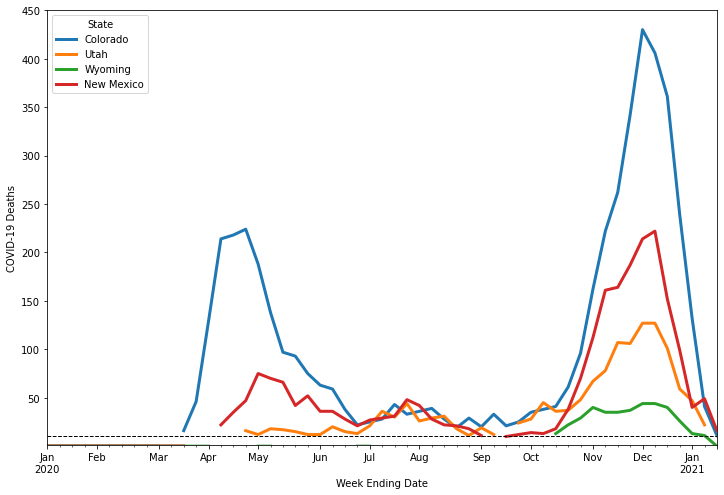

```python
mountain_west_df = covid19_pivot_df.loc['2020-01-01':,['Colorado','Utah','Wyoming','New Mexico']]

f,ax = plt.subplots(figsize=(12,8))
mountain_west_df.plot(ax=ax,lw=3)
ax.set_ylim((1,450))
ax.set_ylabel('COVID-19 Deaths')
ax.legend(title='State',loc='upper left')
ax.axhline(10,c='k',ls='--',lw=1) # Suppressed counts
```

### Create a new dataframe that looks at all causes of death, by state

This will allow us to compare the proportion of all deaths that were attributable to COVID-19

```python
allcause_pivot_df = pd.pivot_table(data = no_bad_rows_df,
                                  index = 'Week Ending Date',
                                  columns = 'Jurisdiction of Occurrence',
                                  values = 'All Cause'
                                 )

allcause_pivot_df.tail()
```

| Jurisdiction of Occurrence Week Ending Date | Alabama | Alaska | Arizona | Arkansas | California | Colorado | Connecticut | Delaware | District of Columbia | Florida | Georgia | Hawaii | Idaho | Illinois | Indiana | Iowa | Kansas | Kentucky | Louisiana | Maine | Maryland | Massachusetts | Michigan | Minnesota | Mississippi | Missouri | Montana | Nebraska | Nevada | … |
| --- | --- | --- | --- | --- | --- | --- | --- | --- | --- | --- | --- | --- | --- | --- | --- | --- | --- | --- | --- | --- | --- | --- | --- | --- | --- | --- | --- | --- | --- | --- |
| 2020-12-19 | 1360.0 | 62.0 | 1972.0 | 839.0 | 7917.0 | 1137.0 | 264.0 | 156.0 | 115.0 | 4711.0 | 1819.0 | 237.0 | 362.0 | 3018.0 | 1644.0 | 767.0 | 889.0 | 991.0 | 906.0 | 323.0 | 1350.0 | 1386.0 | 2588.0 | 1203.0 | 850.0 | 1596.0 | 249.0 | 421.0 | 743.0 | … |
| 2020-12-26 | 1254.0 | 52.0 | 1877.0 | 735.0 | 7279.0 | 969.0 | 201.0 | 152.0 | 108.0 | 4255.0 | 1496.0 | 181.0 | 299.0 | 2748.0 | 1153.0 | 640.0 | 746.0 | 840.0 | 810.0 | 335.0 | 1176.0 | 1401.0 | 2199.0 | 1092.0 | 799.0 | 1364.0 | 255.0 | 359.0 | 681.0 | … |
| 2021-01-02 | 1174.0 | 44.0 | 1585.0 | 673.0 | 5667.0 | 777.0 | 101.0 | 153.0 | 96.0 | 4042.0 | 1358.0 | 186.0 | 185.0 | 2227.0 | 374.0 | 370.0 | 627.0 | 642.0 | 663.0 | 306.0 | 1137.0 | 1181.0 | 1551.0 | 950.0 | 749.0 | 1151.0 | 172.0 | 274.0 | 537.0 | … |
| 2021-01-09 | 797.0 | 37.0 | 1300.0 | 599.0 | 4330.0 | 656.0 | 34.0 | 113.0 | 66.0 | 3413.0 | 937.0 | 159.0 | 102.0 | 1736.0 | 250.0 | 310.0 | 449.0 | 465.0 | 478.0 | 282.0 | 870.0 | 1104.0 | 1084.0 | 683.0 | 522.0 | 858.0 | 128.0 | 195.0 | 456.0 | … |
| 2021-01-16 | 421.0 | 30.0 | 743.0 | 431.0 | 2062.0 | 395.0 | 23.0 | 10.0 | 17.0 | 2223.0 | 444.0 | 117.0 | NaN | 1183.0 | 58.0 | 123.0 | 276.0 | 302.0 | 210.0 | 227.0 | 591.0 | 777.0 | 262.0 | 478.0 | 319.0 | 474.0 | 84.0 | 107.0 | 259.0 | … |

### Now, again looking at the Mountain West states, show a plot of the COVID-19 death fraction

Previously, we saw that Colorado had much larger spikes than its' Mountain West neighbors. Below, we will see that althoguh the total numbers were higher, the total proportion is about the same.

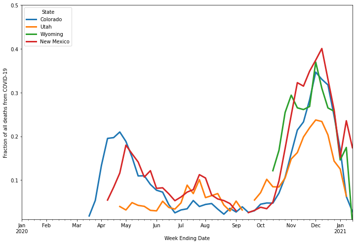

```python
mountain_west_covid19_death_fraction = covid19_pivot_df/allcause_pivot_df
mountain_west_covid19_death_fraction = mountain_west_covid19_death_fraction.loc['2020-01-01':,['Colorado','Utah','Wyoming','New Mexico']]

f,ax = plt.subplots(figsize=(12,8))
mountain_west_covid19_death_fraction.plot(ax=ax,lw=3)
ax.set_ylim((.01,.5))
ax.set_ylabel('Fraction of all deaths from COVID-19')
ax.legend(title='State',loc='upper left')
```

### Now, let's get the total COVID-19 death fraction for all states, and see who has the highest

Remember that this is not the death rate of COVID-19, but rather the proportion of all deaths that COVID-19 is responsible for. We see that, in New Jersey, about 18.5% of its total deaths were caused by COVID-19. On the other end, Vermont only saw slightly more than 1% of deaths caused by COVID-19; a huge difference.

```python
total_death_frac = covid19_pivot_df.loc['2020-01-01':].sum()/allcause_pivot_df.loc['2020-01-01':].sum()
total_death_frac.sort_values(ascending=False)
```

```
Jurisdiction of Occurrence
New Jersey              0.184676
Connecticut             0.154131
South Dakota            0.150728
North Dakota            0.150595
Massachusetts           0.142610
Rhode Island            0.134857
New York                0.134223
Iowa                    0.128357
Mississippi             0.123568
Illinois                0.122233
Texas                   0.119700
Louisiana               0.119521
Arizona                 0.116475
District of Columbia    0.115442
Indiana                 0.115436
Pennsylvania            0.110774
Minnesota               0.109103
New Mexico              0.108600
Maryland                0.108367
Kansas                  0.107274
Nebraska                0.107200
Nevada                  0.104805
Alabama                 0.101362
Michigan                0.100902
Arkansas                0.100744
Colorado                0.100185
Missouri                0.099980
Wisconsin               0.095857
Georgia                 0.094668
Montana                 0.093611
Oklahoma                0.093390
California              0.091644
Ohio                    0.089415
South Carolina          0.088869
Florida                 0.085695
Tennessee               0.084538
Idaho                   0.083662
Virginia                0.073440
Kentucky                0.069134
Wyoming                 0.069131
Delaware                0.066812
Utah                    0.066139
New Hampshire           0.057220
Washington              0.054672
West Virginia           0.049746
Puerto Rico             0.049710
North Carolina          0.046258
Oregon                  0.035398
Maine                   0.023491
Alaska                  0.023169
Hawaii                  0.022680
Vermont                 0.011064
dtype: float64
```

### Now, using the previous data, lets visualize in a horizontal bar chart

The bar chart makes it easy for us to compare which states had the highest proportion of deaths caused by COVID-19.

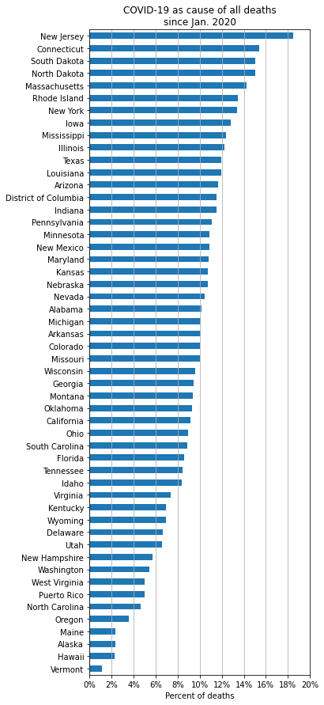

```python
f,ax = plt.subplots(figsize=(5,15))
total_death_frac.sort_values().plot(kind='barh',ax=ax)
ax.set_ylabel(None)
ax.set_title('COVID-19 as cause of all deaths\nsince Jan. 2020')
ax.set_xlabel('Percent of deaths')
ax.set_xticks(np.arange(0,.21,.02))
ax.grid(axis='x')
ax.xaxis.set_major_formatter(ticker.PercentFormatter(1,decimals=0))
```

# Conclusion

> In this analysis, we have looked at how COVID-19 has impacted the United States. Looking at a specific region of interest, the Mountain West, we were able to see how Colorado compares to its neighbors, in terms of COVID-19 deaths as a proportion of total deaths. Although Colorado clearly had more total deaths from COVID-19, we saw that its proportion was quite similar in comparison to Wyoming, Utah, and New Mexico. We did this again for all states to see which states had the highest rates. Seeing New Jersey top that list was not surprising, however, the fact that nearly 1 out of every 5 deaths were attributable to Coronavirus is quite shocking. Being able to see just how much larger the second spike in deaths was makes it more clear about just how deadly this virus is. Ideally, we will not return to the high levels of death, but that will require help from everyone. Obviously, the pandemic has been catastrophic and will leave a lasting impact for years to come. So, it is vital that people get the best information possible, in order to make the best decisions to try and lessen the effect.